# Análisis del fitoplancton frente a Perú durante el año de 1988

Cesar Williams Cueto Torres

## Introducción

La composición y concentración de fitoplancton dependen de las condiciones ambientales y de las masas de agua (Rojas de Mendiola et al., 1985; Ochoa et al., 1985), las concentraciones medias de fitoplancton son mayores en primavera y verano, por tener condiciones favorables de intensidad luminosa y una estratificación en la columna de agua, y menor en invierno donde a pesar de tener intensificado el transporte de aguas ricas en nutrientes hacia superficie, las condiciones de luz y la estratificación en la columna del agua no son favorables para esta comunidad (Zuta & Guillen, 1970; Ochoa & Gómez, 1981, 1988; Rojas de Mendiola, 1981).

El fenómeno conocido como “La Niña”, se da cuando las temperaturas superficiales del agua de mar son más bajas de lo normal, como resultado se da una intensificación en el proceso de surgencia (Philander, 1992; Lukas & Webster, 1992).

El presente trabajo tiene como objetivo analizar el fitoplancton, de acuerdo al tamaño, que se ve beneficiado en épocas cálidas y frías respecto al año 1988.

## Materiales y métodos

Se utilizó los netCDF proporcionados en la carpeta Datos del repositorio C6118-UPCH, los cuales poseen datos de temperatura superficial del mar, salinidad, ph, fitoplancton (grande y pequeño), se requiere la instalación de paquetes rmarkdown, devtools, field, ncdf4, y kali para el completo desarrollo de graficas dentro del programa R.

## Resultados y discusión

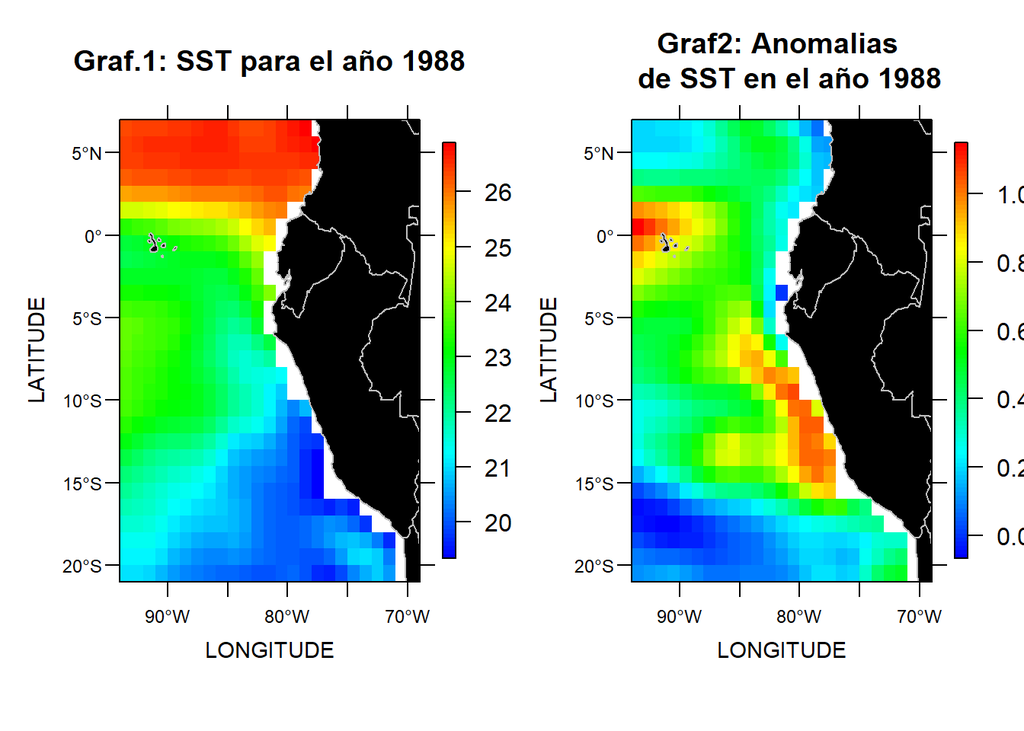

```r
sst_tota = apply(sst[,,1:552], MARGIN = c(1,2), FUN = mean, na.rm = TRUE) #total
sst_1988 = apply(sst[,,348:360], MARGIN = c(1,2), FUN = mean, na.rm = TRUE)
anom = sst_tota - sst_1988

par(mfrow=c(1,2))
image.map(lon, lat, sst_1988, main="Graf.1: SST para el año 1988")
image.map(lon, lat, anom, main="Graf2: Anomalias
  de SST en el año 1988")
```

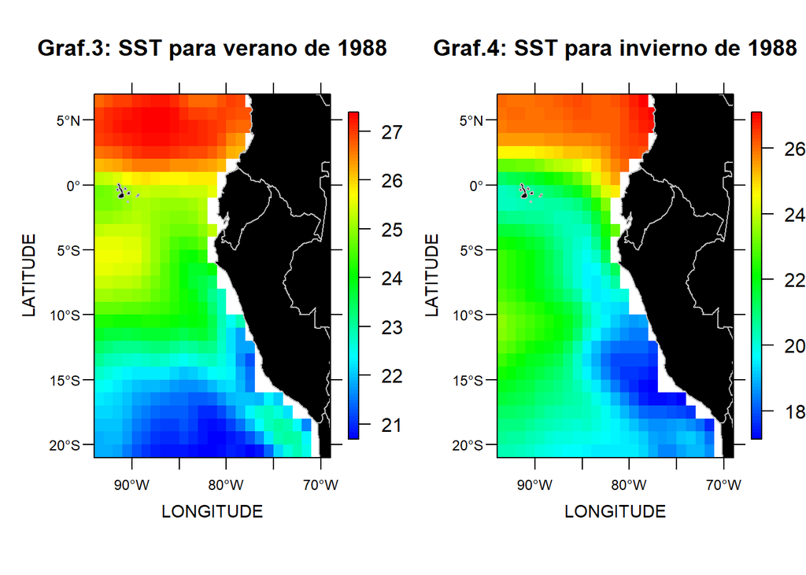

```r
sst_JFM = apply(sst[,,348:350], MARGIN = c(1,2), FUN = mean, na.rm = TRUE) #calido
sst_jas = apply(sst[,,354:356], MARGIN = c(1,2), FUN = mean, na.rm = TRUE) #frio

par(mfrow=c(1,2))
image.map(lon, lat, sst_JFM, main="Graf.3: SST para verano de 1988")
image.map(lon, lat, sst_jas, main="Graf.4: SST para invierno de 1988")
box()
```

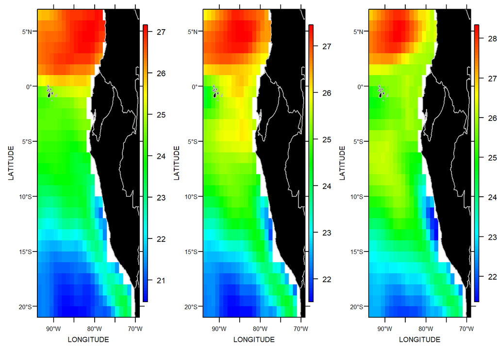

```r
year1988c=time[348:350] ## meses calidos

meses=rep(1:3,length=length(year1988c))

for(i in 1:3){
   apply(sst[,,meses=(1:3)],MARGIN=c(1,2),
         FUN=mean,na.rm=TRUE)}

clim=array(dim=c(dim(sst)[1:2],3))

for(i in 1:3){
   clim[,,i]=apply(sst[,,meses=i],MARGIN=c(1,2),
                   FUN=mean,na.rm=TRUE)
 }
 par(mfrow=c(1,3),mar=c(4,4,1,1))
 for(i in 1:3)
    image.map(lon,lat,clim[,,i])
```

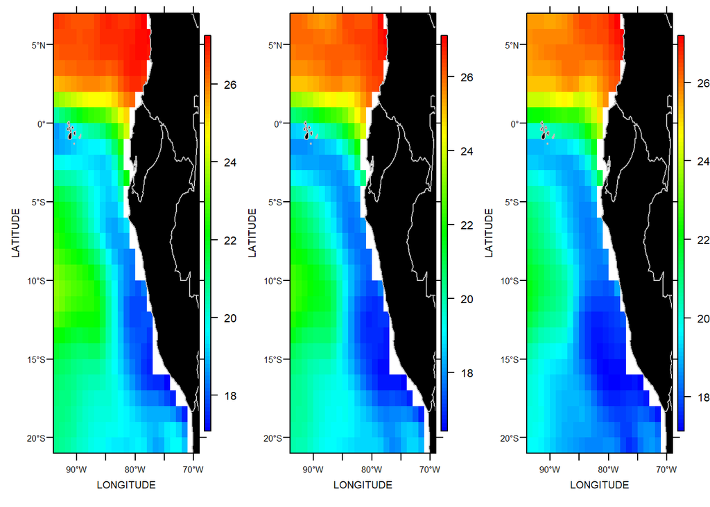

```r
year1988f=time[354:356] ## meses frios

meses=rep(7:9,length=length(year1988f))

for(i in 7:9){
   apply(sst[,,meses=(7:9)],MARGIN=c(1,2),
         FUN=mean,na.rm=TRUE)}

clim=array(dim=c(dim(sst)[1:2],9))

for(i in 7:9){
   clim[,,i]=apply(sst[,,meses=i],MARGIN=c(1,2),
                   FUN=mean,na.rm=TRUE)
 }
 par(mfrow=c(1,3),mar=c(4,4,1,1))
 for(i in 7:9)
    image.map(lon,lat,clim[,,i])
```

fitoplancton grande y pequeño en meses cálidos

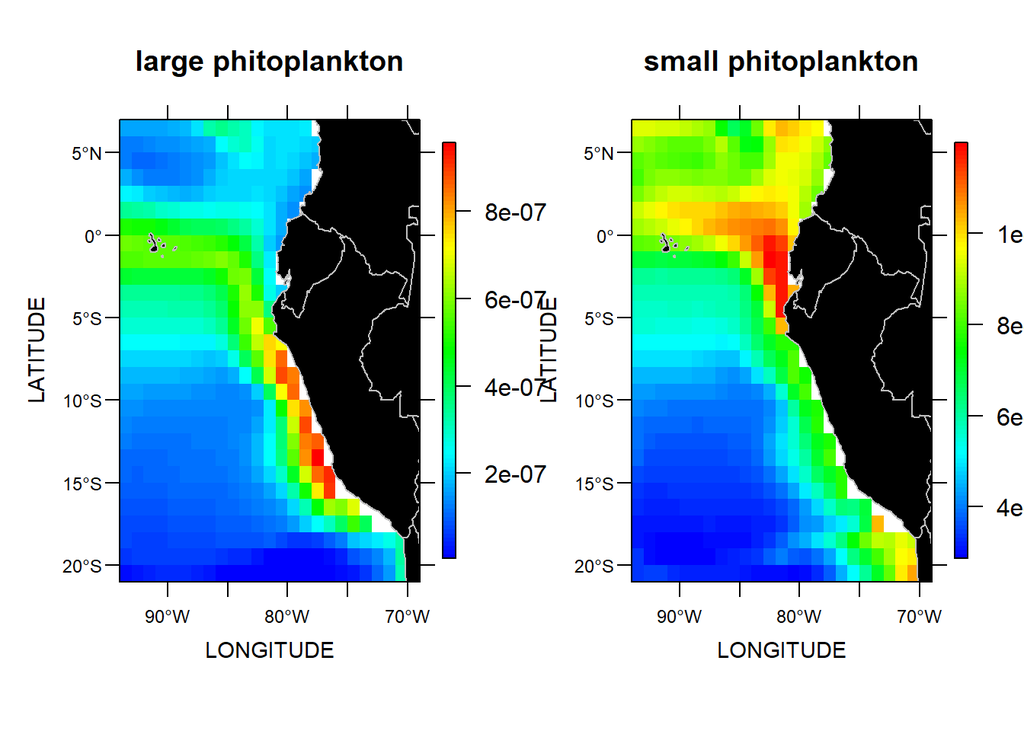

```r
lphy_vera=apply(lphy[,,348:350], MARGIN = c(1,2), FUN = mean, na.rm = TRUE)
sphy_vera=apply(sphy[,,348:350], MARGIN = c(1,2), FUN = mean, na.rm = TRUE)

par(mfrow=c(1,2))
image.map(lon, lat, lphy_vera, main="large phitoplankton")
image.map(lon, lat, sphy_vera, main="small phitoplankton")
```

fitoplancton grande y peqeño en meses frios

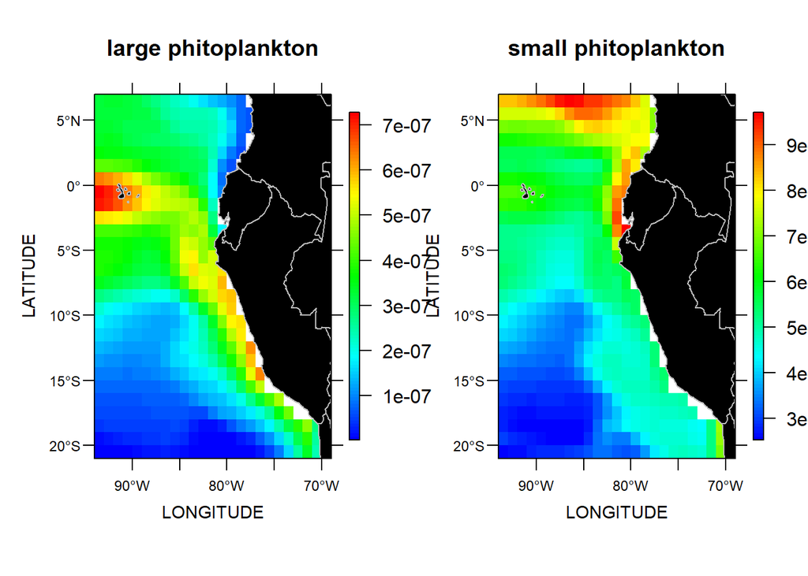

```r
lphy_invr=apply(lphy[,,354:356], MARGIN = c(1,2), FUN = mean, na.rm = TRUE)
sphy_invr=apply(sphy[,,354:356], MARGIN = c(1,2), FUN = mean, na.rm = TRUE)

par(mfrow=c(1,2))
image.map(lon, lat, lphy_invr, main="large phitoplankton")
image.map(lon, lat, sphy_invr, main="small phitoplankton")
```

Gráfico en la cual nos indica la variación del fitoplancton pequeño mientras varia la temperatura promedio del año 1988

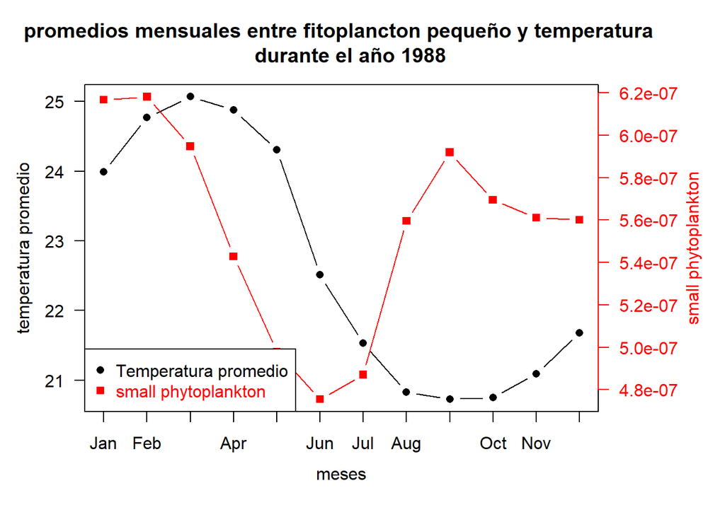

```r
## calculo de datos
temp88 = sst[, , meses=349:360]
promedio=apply(temp88, MARGIN=3,FUN=mean, na.rm=TRUE)
meses88 = rep(1:12, length=length(promedio))
lphy88 = lphy[,,349:360]
promlphy88 = apply(lphy88, MARGIN = 3, FUN = mean, na.rm=TRUE)
sphy88 = sphy[,,349:360]
promsphy88 = apply(sphy88, MARGIN = 3, FUN = mean, na.rm=TRUE)


##adicionando espacio
par(mar=c(5, 4, 4, 6) + 0.1)

## Ploteando los primeros datos y dibujando los ejes
plot(meses88, promedio, pch=16, axes=FALSE, xlab="", ylab="",
   type="b",col="black", main="promedios mensuales entre fitoplancton pequeño y temperatura
   durante el año 1988")
axis(2,col="black",las=1)  ## las=1 tenga forma Horizontal
mtext("temperatura promedio",side=2,line=2.5)
box()

## permite un segundo grafico en el mismo plot
par(new=TRUE)

## ploteando el segundo grafico
plot(meses88, promsphy88, pch=15, xlab="", ylab="",
    axes=FALSE, type="b", col="red")

## colocando titulo al otro eje
mtext("small phytoplankton",side=4,col="red",line=4)
axis(4, col="red",col.axis="red",las=1)

## el eje X
axis(1, at=1:12, labels=month.abb)
mtext("meses",side=1,col="black",line=2.5, xaxt = "n")


## leyenda
legend("bottomleft",legend=c("Temperatura promedio","small phytoplankton"),
  text.col=c("black","red"),pch=c(16,15),col=c("black","red"))
```

En su contraparte, se grafica la grafica para ver el desarrollo del fitoplancton grande en relacion al promedio de temperatura anual de 1988

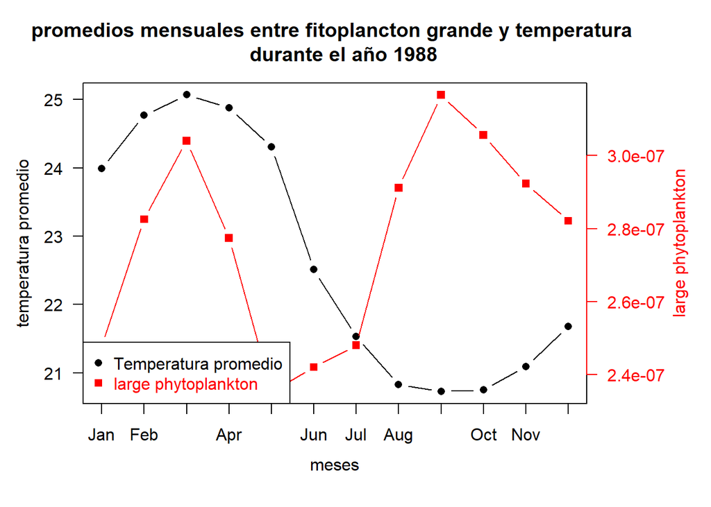

```r
## calculo de datos
temp88 = sst[, , meses=349:360]
promedio=apply(temp88, MARGIN=3,FUN=mean, na.rm=TRUE)
meses88 = rep(1:12, length=length(promedio))
lphy88 = lphy[,,349:360]
promlphy88 = apply(lphy88, MARGIN = 3, FUN = mean, na.rm=TRUE)
sphy88 = sphy[,,349:360]
promsphy88 = apply(sphy88, MARGIN = 3, FUN = mean, na.rm=TRUE)


##adicionando espacio
par(mar=c(5, 4, 4, 6) + 0.1)

## Ploteando los primeros datos y dibujando los ejes
plot(meses88, promedio, pch=16, axes=FALSE, xlab="", ylab="",
   type="b",col="black", main="promedios mensuales entre fitoplancton grande y temperatura
   durante el año 1988")
axis(2,col="black",las=1)  ## las=1 mtome forma horizontal
mtext("temperatura promedio",side=2,line=2.5)
box()

## permite un segundo grafico en el mismo plot
par(new=TRUE)

## ploteando la segunda grafica
plot(meses88, promlphy88, pch=15, xlab="", ylab="",
    axes=FALSE, type="b", col="red")

## colocando titulo al otro eje
mtext("large phytoplankton",side=4,col="red",line=4)
axis(4, col="red",col.axis="red",las=1)

## el eje X
axis(1, at=1:12, labels=month.abb)
mtext("meses",side=1,col="black",line=2.5, xaxt = "n")

## leyenda
legend("bottomleft",legend=c("Temperatura promedio","large phytoplankton"),
  text.col=c("black","red"),pch=c(16,15),col=c("black","red"))
```

## Referencias

• -LUKAS, R., WEBSTER, P. 1992. Toga-Coare. Oceanus 35(4): 62-65 pp.  
• -OCHOA, N., TARAZONA, A., 2003. Small scale temporal variability in the phytoplankton of Independencia Bay, Pisco, Peru. Rev. Perú biol. v.10 n.1 Lima ene./jul. 2003.  
• -OCHOA, N., GOMEZ, O., 1988, Variaciones Espacio-Temporales del fitoplancton frente a Callao, Perú, e 1986. In: Salzwedel, H. y Landa, A. (Eds). Boletin Vol. Extraordinario Instituto del Mar del Perú. Recursos y dinámica del ecosistema de afloramiento Peruano. 1:51-59.  
• -OCHOA, N,. ROJAS DE MENDIOLA, B., GOMEZ, O., 1985, Identificación del Fenómeno “El Niño” a través de lo organismos fitoplanctonicos. Bol.Ins.del Mar. Vol.Extraordinario “El Niño” y su impacto en la Fauna Marina Ed. Arntz, w.; A, Tarazona, J.:23-31.  
• -OCHOA, N., GOMEZ, O., 1981, Variaciones del fitoplancton en el área de Chimbote durante 1977. Bol.Inst. del Mar del Perú. Vol.Extraordinario ICANE. Callao. Perú 119-128.  
• -PHILANDER, G. S., 1992, El Niño, Oceanus 35)(4): 56-61.  
• -VINOGRADOV, M., E., SHUSKINA, E.A., 1984, Succession of marine epipelagic communities. Mar. Ecol. Prog. Ser., 16:229-239.  
• -ZUTA, S., GUILLEN, O., 1970, Oceanografía de las aguas costeras del Perú. Bol. Inst. Mar del Perú. 2(5):161-234.  
• -ROJAS DE MENDIOLA, B., GOMEZ, O., OCHOA, N., 1985, Efectos del fenómeno “El Niño” 1982-1983 sobre fitoplancton de las costas peruanas. Simp.Int.Alf.O.Afr.Inst.Inv.Pesq. Barcelona 1:417-434.